# Explore Yelp Dataset

## Part 2: Sentiment Analysis of Yelp Reviews

### By Yayin Cai, April 18th

In the previous analysis (see **Explore Yelp Dataset Part 1**), we analyzed the yelp dataset using PySpark and Spark SQL. Today, we would like to narrow down our analysis to a city and perform sentiment analysis on the Yelp reviews. In the analysis, we choose Pittsburgh as the study area.

## 1. Does Sentiment Analysis Work?

In this part, we'll load the data, perform a sentiment analysis, and explore the results.

### 1.1 Loading Datasets

First, we load the dataset, including the business information and the reviews.

```python
import pandas as pd

yelp_pittsburgh_reviews = pd.read_json("reviews_pittsburgh.json", orient = 'records', lines = True)
```

```python
yelp_pittsburgh_business = pd.read_json("restaurants_pittsburgh.json", orient = 'records', lines = True)
```

```python
print("There are", str(len(yelp_pittsburgh_reviews)),"reviews in Pittsburgh")
print("There are", str(len(yelp_pittsburgh_business)),"restaurants in Pittsburgh")
```

```
There are 162104 reviews in Pittsburgh
There are 2453 restaurants in Pittsburgh
```

### 1.2 Simple Data Wrangling

#### 1.2.1 Format the review text

The first step is to split the review text into its individual words and make all of the words lower-cased.

```python
def split_text(string):
    string = string.lower()
    textlist = string.split()
    return textlist
```

```python
yelp_pittsburgh_reviews["formatted_text"] = yelp_pittsburgh_reviews["text"].apply(lambda x: split_text(x))
```

```python
yelp_pittsburgh_reviews.head()
```

|  | business_id | review_id | stars | text | formatted_text |
| --- | --- | --- | --- | --- | --- |
| 0 | eU_713ec6fTGNO4BegRaww | fdiNeiN_hoCxCMy2wTRW9g | 4 | I'll be the first to admit that I was not exci... | [i'll, be, the, first, to, admit, that, i, was... |
| 1 | FxLfqxdYPA6Z85PFKaqLrg | Z7wgXp98wYB57QdRY3HQ3w | 4 | Wow. So surprised at the one and two star revi... | [wow., so, surprised, at, the, one, and, two, ... |
| 2 | 9nTF596jDvBBia2EXXiOOg | 1daGBpea0sleayFeeXuoYw | 1 | if i can give this place no stars i would, i o... | [if, i, can, give, this, place, no, stars, i, ... |
| 3 | sMzNLdhJZGzYirIWt-fMAg | RLbWoIri29BcQ8yjzsvQLQ | 5 | This place epitomizes the rumored transformati... | [this, place, epitomizes, the, rumored, transf... |
| 4 | hcFSc0OHgZJybnjQBrL_8Q | vAckaF8n0KKJeqHOnb1ayw | 4 | Here's why I don't write reviews for Chinese r... | [here's, why, i, don't, write, reviews, for, c... |

#### 1.2.2 Review stop words

Next, we want to remove any stop words from the list of words in each review.

```python
from nltk.corpus import stopwords
```

```python
stop_words = set(stopwords.words('english'))

def remove_stop(word_list):
    filtered_list = [w for w in word_list if (not w in stop_words)]
    return filtered_list
```

```python
yelp_pittsburgh_reviews["formatted_text"] = yelp_pittsburgh_reviews["formatted_text"].apply(lambda x: remove_stop(x))
```

```python
yelp_pittsburgh_reviews.head()
```

|  | business_id | review_id | stars | text | formatted_text |
| --- | --- | --- | --- | --- | --- |
| 0 | eU_713ec6fTGNO4BegRaww | fdiNeiN_hoCxCMy2wTRW9g | 4 | I'll be the first to admit that I was not exci... | [i'll, first, admit, excited, going, la, tavol... |
| 1 | FxLfqxdYPA6Z85PFKaqLrg | Z7wgXp98wYB57QdRY3HQ3w | 4 | Wow. So surprised at the one and two star revi... | [wow., surprised, one, two, star, reviews!, st... |
| 2 | 9nTF596jDvBBia2EXXiOOg | 1daGBpea0sleayFeeXuoYw | 1 | if i can give this place no stars i would, i o... | [give, place, stars, would,, hot, pot, though,... |
| 3 | sMzNLdhJZGzYirIWt-fMAg | RLbWoIri29BcQ8yjzsvQLQ | 5 | This place epitomizes the rumored transformati... | [place, epitomizes, rumored, transformation, p... |
| 4 | hcFSc0OHgZJybnjQBrL_8Q | vAckaF8n0KKJeqHOnb1ayw | 4 | Here's why I don't write reviews for Chinese r... | [here's, write, reviews, chinese, restaurants:... |

### 1.3 Sentiment Analysis

#### 1.3.1 Calculate polarity and subjectivity

Then, we can extract the `subjectivity` and `polarity` from the `formatted_text`.

```python
from textblob import TextBlob

import warnings
warnings.filterwarnings("ignore")
```

```python
def get_sentiment(word_list):
    sentence = " ".join(word_list)
    sentiment = TextBlob(sentence).sentiment
    return pd.Series([sentiment[0], sentiment[1]])
```

```python
yelp_pittsburgh_reviews[["polarity", "subjectivity"]] = yelp_pittsburgh_reviews["formatted_text"].apply(lambda x: get_sentiment(x))
```

```python
yelp_pittsburgh_reviews.head()
```

|  | business_id | review_id | stars | text | formatted_text | polarity | subjectivity |
| --- | --- | --- | --- | --- | --- | --- | --- |
| 0 | eU_713ec6fTGNO4BegRaww | fdiNeiN_hoCxCMy2wTRW9g | 4 | I'll be the first to admit that I was not exci... | [i'll, first, admit, excited, going, la, tavol... | 0.245505 | 0.609437 |
| 1 | FxLfqxdYPA6Z85PFKaqLrg | Z7wgXp98wYB57QdRY3HQ3w | 4 | Wow. So surprised at the one and two star revi... | [wow., surprised, one, two, star, reviews!, st... | 0.597787 | 0.818427 |
| 2 | 9nTF596jDvBBia2EXXiOOg | 1daGBpea0sleayFeeXuoYw | 1 | if i can give this place no stars i would, i o... | [give, place, stars, would,, hot, pot, though,... | 0.053869 | 0.664137 |
| 3 | sMzNLdhJZGzYirIWt-fMAg | RLbWoIri29BcQ8yjzsvQLQ | 5 | This place epitomizes the rumored transformati... | [place, epitomizes, rumored, transformation, p... | 0.266667 | 0.416667 |
| 4 | hcFSc0OHgZJybnjQBrL_8Q | vAckaF8n0KKJeqHOnb1ayw | 4 | Here's why I don't write reviews for Chinese r... | [here's, write, reviews, chinese, restaurants:... | 0.227083 | 0.557576 |

#### 1.3.2 Comparing the sentiment analysis to number of stars

We can make two box plots, one showing the polarity vs number of user stars and one showing the subjectivity vs the number of user stars.

```python
import matplotlib.pyplot as plt
import seaborn as sns
palette = ["#ffffcc", "#a1dab4", "#41b6c4", "#2c7fb8", "#253494"]
```

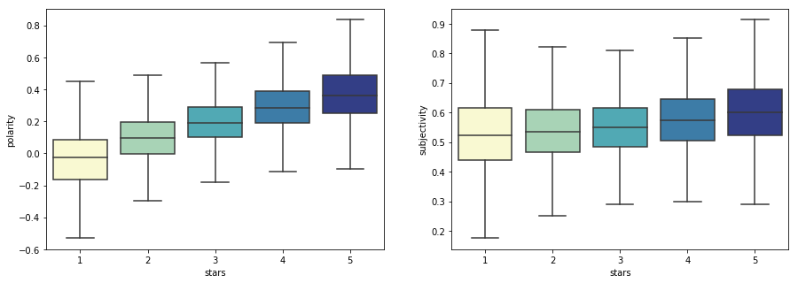

```python
fig, axes = plt.subplots(nrows=1, ncols=2, figsize=(15, 5))
polarity = sns.boxplot(x = "stars", y = "polarity", data = yelp_pittsburgh_reviews, palette=palette, \
                         showfliers=False, ax=axes[0])
subjectivity = sns.boxplot(x = "stars", y = "subjectivity", data = yelp_pittsburgh_reviews, palette=palette, \
                         showfliers=False, ax=axes[1])
```

From the above charts, it is obvious that polarity indicates the effectiveness of our sentiment analysis better.

### 1.4 The Importance of Individual Words

In this part, we'll explore the importance and frequency of individual words in Yelp reviews. We will identify the most common reviews and then plot the average polarity vs the user stars for the reviews where those words occur.

#### 1.4.1 Re-format the data

Now, we want to reshape the dataset to extract individual words.

```python
def reshape_data(review_subset):
    from pandas import Series, merge

    X = (review_subset['formatted_text'].apply(Series).stack().reset_index(level=1, drop=True).to_frame('word'))

    R = review_subset[['polarity', 'stars', 'review_id']]

    return merge(R, X, left_index = True, right_index = True).reset_index(drop=True)
```

```python
yelp_pittsburgh_reviews_reshape = reshape_data(yelp_pittsburgh_reviews)
```

```python
yelp_pittsburgh_reviews_reshape.head()
```

|  | polarity | stars | review_id | word |
| --- | --- | --- | --- | --- |
| 0 | 0.245505 | 4 | fdiNeiN_hoCxCMy2wTRW9g | i'll |
| 1 | 0.245505 | 4 | fdiNeiN_hoCxCMy2wTRW9g | first |
| 2 | 0.245505 | 4 | fdiNeiN_hoCxCMy2wTRW9g | admit |
| 3 | 0.245505 | 4 | fdiNeiN_hoCxCMy2wTRW9g | excited |
| 4 | 0.245505 | 4 | fdiNeiN_hoCxCMy2wTRW9g | going |

#### 1.4.2 Calculate the average number of stars and polarity for each word

1. the size of each group
2. the average number of user stars for each word
3. the average polarity for each word

```python
yelp_pittsburgh_words = yelp_pittsburgh_reviews_reshape.groupby("word").agg({"review_id":"count",\
                                                                            "stars":"mean", "polarity":"mean"})
```

```python
yelp_pittsburgh_words = yelp_pittsburgh_words.reset_index()
```

```python
yelp_pittsburgh_words.columns = ["word","count","stars","polarity"]
yelp_pittsburgh_words = yelp_pittsburgh_words.sort_values("count", ascending = False)
```

```python
yelp_pittsburgh_words.head()
```

|  | word | count | stars | polarity |
| --- | --- | --- | --- | --- |
| 122973 | food | 89390 | 3.516266 | 0.228413 |
| 205413 | place | 71376 | 3.705545 | 0.238644 |
| 132442 | good | 65007 | 3.722076 | 0.283236 |
| 163773 | like | 59303 | 3.452692 | 0.195326 |
| 134417 | great | 57381 | 4.219777 | 0.361753 |

```python
print("There are", str(len(yelp_pittsburgh_words)), "words in the dataset.")
```

```
There are 290102 words in the dataset.
```

#### 1.4.3 Select words the occur at least 100 times in reviews

We don't really care about all words in the reviews. We want to trim our DataFrame from the last section to only include words that occurred at least 100 times.

```python
yelp_pittsburgh_words = yelp_pittsburgh_words[yelp_pittsburgh_words["count"]>=100]
```

```python
print("After trimming, there are", str(len(yelp_pittsburgh_words)), "words in the dataset.")
```

```
After trimming, there are 8385 words in the dataset.
```

#### 1.4.4 Plot the average polarity vs user stars

Here, we can make a scatter plot of the average user stars vs average polarity for the words in the data frame from the last section.

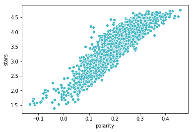

```python
polarity_stars = sns.scatterplot(x = "polarity", y = "stars", data = yelp_pittsburgh_words, color = "#41b6c4")
```

## 2. Correlating Restaurant Data and Household Income

In this part, we'll use the census API to download household income data and overlay restaurant locations.

### 2.1 Query the Census API

https://api.census.gov/data/2017/acs/acs5/variables.html

The FIPS codes for Pittsburgh is:

```
- PA code: '42'
- City code: '61000'
```

```python
from census_area import Census

c = Census("49b0c4cbc185fba5e22518121a9335b226f5d02e")
HH_income = c.acs5.state_place_tract(('NAME', 'B19013_001E'), 42, 61000, return_geometry = True)
```

```python
HH_income_dict = HH_income.get("features")
```

```python
HH_income_df = pd.DataFrame(HH_income_dict)
```

```python
HH_income_df.head()
```

|  | geometry | properties | type |
| --- | --- | --- | --- |
| 0 | {'type': 'Polygon', 'coordinates': [[[-80.0719... | {'OBJECTID': 2935, 'AREALAND': 881779, 'AREAWA... | Feature |
| 1 | {'type': 'Polygon', 'coordinates': [[[-80.0512... | {'OBJECTID': 6831, 'AREALAND': 2532255, 'AREAW... | Feature |
| 2 | {'type': 'Polygon', 'coordinates': [[[-80.0628... | {'OBJECTID': 60097, 'AREALAND': 1328964, 'AREA... | Feature |
| 3 | {'type': 'Polygon', 'coordinates': [[[-80.0612... | {'OBJECTID': 27369, 'AREALAND': 617106, 'AREAW... | Feature |
| 4 | {'type': 'Polygon', 'coordinates': [[[-79.9923... | {'OBJECTID': 27370, 'AREALAND': 1453893, 'AREA... | Feature |

```python
from shapely import geometry
```

```python
def get_geometry(dictionary):
    geom = dictionary.get("coordinates")[0]
    poly = geometry.Polygon(geom)
    #poly = poly.wkt
    return poly
```

```python
HH_income_df["the_geo"] = HH_income_df["geometry"].apply(lambda x: get_geometry(x))
```

```python
HH_income_df.head()
```

|  | geometry | properties | type | the_geo |
| --- | --- | --- | --- | --- |
| 0 | {'type': 'Polygon', 'coordinates': [[[-80.0719... | {'OBJECTID': 2935, 'AREALAND': 881779, 'AREAWA... | Feature | POLYGON ((-80.07199799999999 40.453356, -80.07... |
| 1 | {'type': 'Polygon', 'coordinates': [[[-80.0512... | {'OBJECTID': 6831, 'AREALAND': 2532255, 'AREAW... | Feature | POLYGON ((-80.051202 40.401943, -80.050837 40.... |
| 2 | {'type': 'Polygon', 'coordinates': [[[-80.0628... | {'OBJECTID': 60097, 'AREALAND': 1328964, 'AREA... | Feature | POLYGON ((-80.06283999999999 40.448545, -80.06... |
| 3 | {'type': 'Polygon', 'coordinates': [[[-80.0612... | {'OBJECTID': 27369, 'AREALAND': 617106, 'AREAW... | Feature | POLYGON ((-80.061216 40.440632, -80.061133 40.... |
| 4 | {'type': 'Polygon', 'coordinates': [[[-79.9923... | {'OBJECTID': 27370, 'AREALAND': 1453893, 'AREA... | Feature | POLYGON ((-79.992332 40.406587, -79.992323 40.... |

```python
def get_properties(df, prop):
    properties = df[prop].apply(pd.Series)
    df = pd.concat([df, properties], axis=1)
    return df
```

```python
HH_income_df = get_properties(HH_income_df, "properties")
```

```python
HH_income_df.head()
```

|  | geometry | properties | type | the_geo | OBJECTID | AREALAND | AREAWATER | COUNTY | FUNCSTAT | GEOID | ... | CENTLON | CENTLAT | INTPTLON | INTPTLAT | STGEOMETRY.AREA | STGEOMETRY.LEN | B19013_001E | state | county | tract |
| --- | --- | --- | --- | --- | --- | --- | --- | --- | --- | --- | --- | --- | --- | --- | --- | --- | --- | --- | --- | --- | --- |
| 0 | {'type': 'Polygon', 'coordinates': [[[-80.0719... | {'OBJECTID': 2935, 'AREALAND': 881779, 'AREAWA... | Feature | POLYGON ((-80.07199799999999 40.453356, -80.07... | 2935 | 881779 | 0 | 003 | S | 42003202200 | ... | -080.0636247 | +40.4540547 | -080.0636247 | +40.4540547 | 1.524536e+06 | 6649.036020 | 41964.0 | 42 | 003 | 202200 |
| 1 | {'type': 'Polygon', 'coordinates': [[[-80.0512... | {'OBJECTID': 6831, 'AREALAND': 2532255, 'AREAW... | Feature | POLYGON ((-80.051202 40.401943, -80.050837 40.... | 6831 | 2532255 | 0 | 003 | S | 42003202300 | ... | -080.0392970 | +40.4103004 | -080.0392970 | +40.4103004 | 4.372478e+06 | 10137.272451 | 58179.0 | 42 | 003 | 202300 |
| 2 | {'type': 'Polygon', 'coordinates': [[[-80.0628... | {'OBJECTID': 60097, 'AREALAND': 1328964, 'AREA... | Feature | POLYGON ((-80.06283999999999 40.448545, -80.06... | 60097 | 1328964 | 0 | 003 | S | 42003281400 | ... | -080.0519580 | +40.4471360 | -080.0519580 | +40.4471360 | 2.297229e+06 | 6346.953399 | 32969.0 | 42 | 003 | 281400 |
| 3 | {'type': 'Polygon', 'coordinates': [[[-80.0612... | {'OBJECTID': 27369, 'AREALAND': 617106, 'AREAW... | Feature | POLYGON ((-80.061216 40.440632, -80.061133 40.... | 27369 | 617106 | 0 | 003 | S | 42003281500 | ... | -080.0539288 | +40.4404623 | -080.0539288 | +40.4404623 | 1.066508e+06 | 4669.731854 | 46818.0 | 42 | 003 | 281500 |
| 4 | {'type': 'Polygon', 'coordinates': [[[-79.9923... | {'OBJECTID': 27370, 'AREALAND': 1453893, 'AREA... | Feature | POLYGON ((-79.992332 40.406587, -79.992323 40.... | 27370 | 1453893 | 0 | 003 | S | 42003290200 | ... | -079.9838310 | +40.3993660 | -079.9838310 | +40.3993660 | 2.509650e+06 | 8376.186094 | 40139.0 | 42 | 003 | 290200 |

5 rows × 27 columns

```python
HH_income_df = HH_income_df.drop(["geometry","properties"], axis=1)
```

### 2.2 Convert the DataFrame to a GeoDataFrame

Now, we are going to convert the DataFrame to a GeoDataFrame.

```python
import geopandas as gpd
crs = {'init': 'epsg:4326'}
HH_income_gdf = gpd.GeoDataFrame(HH_income_df, crs = crs, geometry = "the_geo")
```

```python
HH_income_gdf.head()
```

|  | type | the_geo | OBJECTID | AREALAND | AREAWATER | COUNTY | FUNCSTAT | GEOID | LSADC | MTFCC | ... | CENTLON | CENTLAT | INTPTLON | INTPTLAT | STGEOMETRY.AREA | STGEOMETRY.LEN | B19013_001E | state | county | tract |
| --- | --- | --- | --- | --- | --- | --- | --- | --- | --- | --- | --- | --- | --- | --- | --- | --- | --- | --- | --- | --- | --- |
| 0 | Feature | POLYGON ((-80.07199799999999 40.453356, -80.07... | 2935 | 881779 | 0 | 003 | S | 42003202200 | CT | G5020 | ... | -080.0636247 | +40.4540547 | -080.0636247 | +40.4540547 | 1.524536e+06 | 6649.036020 | 41964.0 | 42 | 003 | 202200 |
| 1 | Feature | POLYGON ((-80.051202 40.401943, -80.050837 40.... | 6831 | 2532255 | 0 | 003 | S | 42003202300 | CT | G5020 | ... | -080.0392970 | +40.4103004 | -080.0392970 | +40.4103004 | 4.372478e+06 | 10137.272451 | 58179.0 | 42 | 003 | 202300 |
| 2 | Feature | POLYGON ((-80.06283999999999 40.448545, -80.06... | 60097 | 1328964 | 0 | 003 | S | 42003281400 | CT | G5020 | ... | -080.0519580 | +40.4471360 | -080.0519580 | +40.4471360 | 2.297229e+06 | 6346.953399 | 32969.0 | 42 | 003 | 281400 |
| 3 | Feature | POLYGON ((-80.061216 40.440632, -80.061133 40.... | 27369 | 617106 | 0 | 003 | S | 42003281500 | CT | G5020 | ... | -080.0539288 | +40.4404623 | -080.0539288 | +40.4404623 | 1.066508e+06 | 4669.731854 | 46818.0 | 42 | 003 | 281500 |
| 4 | Feature | POLYGON ((-79.992332 40.406587, -79.992323 40.... | 27370 | 1453893 | 0 | 003 | S | 42003290200 | CT | G5020 | ... | -079.9838310 | +40.3993660 | -079.9838310 | +40.3993660 | 2.509650e+06 | 8376.186094 | 40139.0 | 42 | 003 | 290200 |

5 rows × 25 columns

Let's check the maximum and minimum median household income on census tract level.

```python
HH_income_gdf["B19013_001E"].max()
```

```
177824.0
```

```python
HH_income_gdf["B19013_001E"].min()
```

```
-666666666.0
```

Obviously, the minimum value is incorrect. It is highly likely that there is no population in the census tract, so there is no data for these census tracts.

### 2.3 Plot a choropleth map of the household income

We can plot the median household income.

```python
def plotMap(geodf, figwidth, figheight, column):
    validmin = geodf[geodf[column]>=0][column].min()

    vmin, vmax = geodf[geodf[column]>=validmin][column].min(),geodf[column].max()

    fig, ax = plt.subplots(1, figsize=(figwidth, figheight))

    geodf[geodf[column]<validmin].plot(color="#cccccc", ax=ax)
    geodf[geodf[column]>=validmin].plot(cmap = 'GnBu',column = column, linewidth=0.8, ax=ax, edgecolor='0.8')
    ax.axis('off')
    sm = plt.cm.ScalarMappable(cmap = 'GnBu',norm = plt.Normalize(vmin=vmin, vmax=vmax))
    sm._A = []
    cbar = fig.colorbar(sm)
```

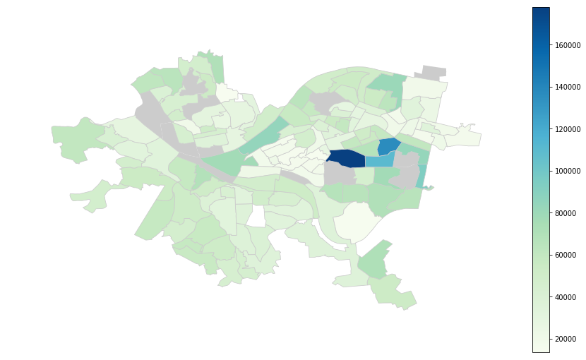

```python
plotMap(HH_income_gdf, 15,9, "B19013_001E")
```

### 2.4 Load the Restaurants Data

We want to generate the GeoDataFrame of restaurant data as well.

```python
from shapely.geometry import Point

def create_point(df, lon, lat):
    geometry = [Point(xy) for xy in zip(df[lon], df[lat])]
    crs = {'init': 'epsg:4326'}
    gdf = gpd.GeoDataFrame(df, crs = crs, geometry = geometry)
    return gdf
```

```python
yelp_pittsburgh_business_gdf = create_point(yelp_pittsburgh_business, "longitude", "latitude")
```

```python
yelp_pittsburgh_business_gdf.head()
```

|  | business_id | latitude | longitude | name | review_count | stars | geometry |
| --- | --- | --- | --- | --- | --- | --- | --- |
| 0 | 1RHY4K3BD22FK7Cfftn8Mg | 40.496177 | -80.246011 | Marathon Diner | 35 | 4.0 | POINT (-80.24601123639999 40.4961769456) |
| 1 | dQj5DLZjeDK3KFysh1SYOQ | 40.465694 | -79.949324 | Apteka | 242 | 4.5 | POINT (-79.9493238 40.4656937) |
| 2 | v-scZMU6jhnmV955RSzGJw | 40.441062 | -80.002126 | No. 1 Sushi Sushi | 106 | 4.5 | POINT (-80.002126 40.441062) |
| 3 | t-6tdxRaz7s9a0sf94Tguw | 40.462345 | -79.924165 | Impressionz | 29 | 4.5 | POINT (-79.92416515950001 40.4623454064) |
| 4 | 5WMIvoMx3l1vn1uJ3HZB6Q | 40.442863 | -79.996412 | Subway | 3 | 3.0 | POINT (-79.99641200000001 40.4428627) |

### 2.5 Overlay Restaurants on the Income Map

Now, we want to overlay the restaurants on the income map.

```python
[xmin, ymin, xmax, ymax] = HH_income_gdf.geometry.total_bounds
```

```python
import numpy as np

yelp_pittsburgh_business_gdf["star_level"] = np.where(yelp_pittsburgh_business_gdf["stars"]<3, "1 - 2.5",
                                             np.where(yelp_pittsburgh_business_gdf["stars"]<4, "3 - 3.5","4 - 5"))
```

```python
def plotMapCombine(basedf, geodf, figwidth, figheight, columnbase, column):
    fig, ax = plt.subplots(1, figsize=(figwidth, figheight))
    base = basedf.plot(cmap='GnBu', ax=ax)

    [xmin, ymin, xmax, ymax] = basedf.geometry.total_bounds

    plt.xlim(xmin-0.01, xmax+0.01)
    plt.ylim(ymin-0.01, ymax+0.01)

    validmin = basedf[basedf[columnbase]>=0][columnbase].min()
    vmin, vmax = basedf[basedf[columnbase]>=validmin][columnbase].min(),basedf[columnbase].max()

    basedf[basedf[columnbase] < validmin].plot(color = "#cccccc", ax=ax)
    basedf[basedf[columnbase] >= validmin].plot(cmap = 'GnBu', column = columnbase, \
                                                linewidth = 0.8, ax = ax, edgecolor = '0.8')

    geodf.plot(column = column, ax = base, markersize=5, cmap = "YlOrRd", legend = True)

    ax.axis('off')
    sm = plt.cm.ScalarMappable(cmap = 'GnBu',norm = plt.Normalize(vmin = vmin, vmax = vmax))
    sm._A = []
    cbar = fig.colorbar(sm)
```

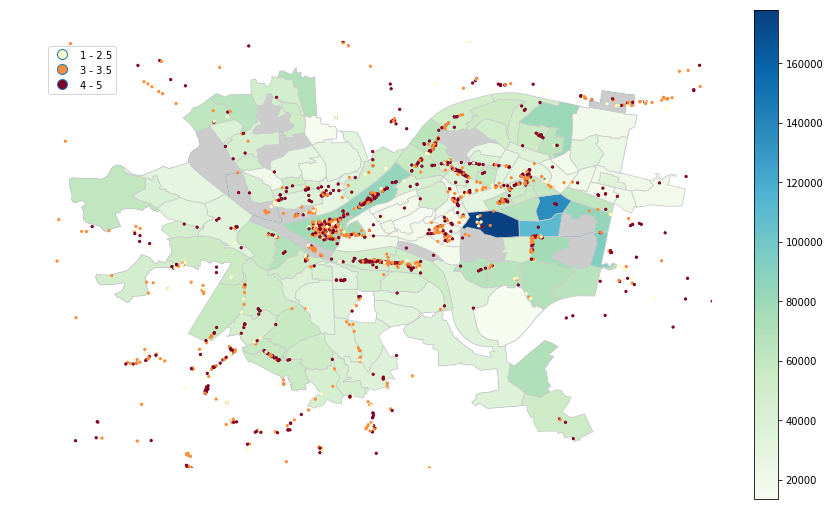

```python
plotMapCombine(HH_income_gdf, yelp_pittsburgh_business_gdf, 15, 9, "B19013_001E", "star_level")
```

### 2.6 Comparing Polarity vs. Stars Geographically

We've already known that polarity is highly associated with the stars. We also want to compare the spatial distribution of restaurants' polarity and stars.

```python
restaurants_sentiment = yelp_pittsburgh_reviews.groupby("business_id")["polarity"].mean()
restaurants_sentiment = restaurants_sentiment.reset_index()
restaurants_sentiment.columns = ["business_id","polarity"]
```

```python
restaurants_sentiment.head()
```

|  | business_id | polarity |
| --- | --- | --- |
| 0 | --ujyvoQlwVoBgMYtADiLA | 0.302486 |
| 1 | -1xCh7Cocn6IwFzhELyohA | 0.190149 |
| 2 | -3rvpkYkYD_N1IP4hSvD0A | 0.178506 |
| 3 | -40RDS4F54qiGiEQUsZaXA | 0.356283 |
| 4 | -7H-oXvCxJzuT42ky6Db0g | 0.236090 |

```python
yelp_pittsburgh_business_merge = pd.merge(yelp_pittsburgh_business_gdf, restaurants_sentiment, on = "business_id", how = "inner")
```

```python
yelp_pittsburgh_business_merge.head()
```

|  | business_id | latitude | longitude | name | review_count | stars | geometry | star_level | polarity |
| --- | --- | --- | --- | --- | --- | --- | --- | --- | --- |
| 0 | 1RHY4K3BD22FK7Cfftn8Mg | 40.496177 | -80.246011 | Marathon Diner | 35 | 4.0 | POINT (-80.24601123639999 40.4961769456) | 4 - 5 | 0.257575 |
| 1 | dQj5DLZjeDK3KFysh1SYOQ | 40.465694 | -79.949324 | Apteka | 242 | 4.5 | POINT (-79.9493238 40.4656937) | 4 - 5 | 0.330375 |
| 2 | v-scZMU6jhnmV955RSzGJw | 40.441062 | -80.002126 | No. 1 Sushi Sushi | 106 | 4.5 | POINT (-80.002126 40.441062) | 4 - 5 | 0.325628 |
| 3 | t-6tdxRaz7s9a0sf94Tguw | 40.462345 | -79.924165 | Impressionz | 29 | 4.5 | POINT (-79.92416515950001 40.4623454064) | 4 - 5 | 0.237149 |
| 4 | 5WMIvoMx3l1vn1uJ3HZB6Q | 40.442863 | -79.996412 | Subway | 3 | 3.0 | POINT (-79.99641200000001 40.4428627) | 3 - 3.5 | 0.029696 |

```python
print("There are", str(len(yelp_pittsburgh_business)),"in total.")
print("There are", str(len(yelp_pittsburgh_business_merge)),"with reviews.")
```

```
There are 2453 in total.
There are 2453 with reviews.
```

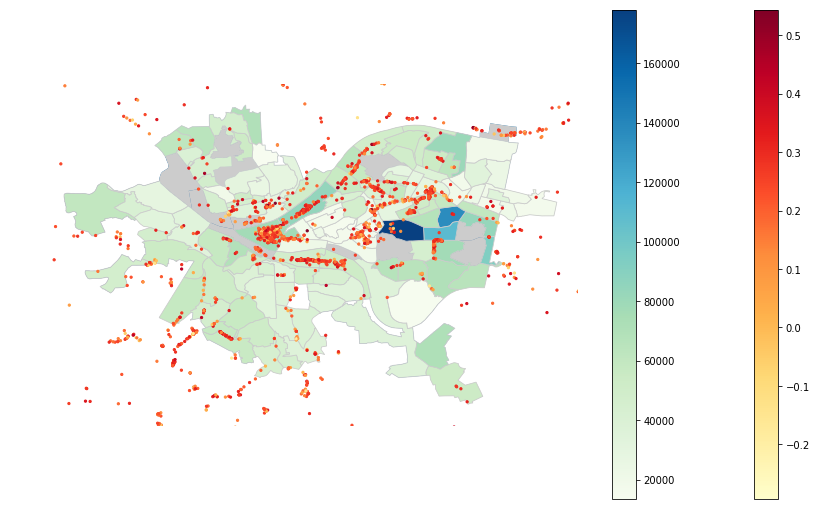

```python
plotMapCombine(HH_income_gdf, yelp_pittsburgh_business_merge, 15, 9, "B19013_001E", "polarity")
```

```python
def plotMapTwo(basedf, geodf, figwidth, figheight, column1, column2):
    fig, axes = plt.subplots(nrows=1, ncols=2, figsize=(figwidth, figheight))
    base1 = basedf.plot(color = "white", edgecolor='grey', ax=axes[0])
    base2 = basedf.plot(color = "white", edgecolor='grey', ax=axes[1])

    [xmin, ymin, xmax, ymax] = basedf.geometry.total_bounds

    axes[0].set_xlim(xmin-0.01, xmax+0.01)
    axes[0].set_ylim(ymin-0.01, ymax+0.01)

    axes[1].set_xlim(xmin-0.01, xmax+0.01)
    axes[1].set_ylim(ymin-0.01, ymax+0.01)

    axes[0].set_title(column1)
    axes[1].set_title(column2)

    geodf.plot(column = column1, ax = base1, markersize=5, cmap = "YlOrRd", legend = True)
    geodf.plot(column = column2, ax = base2, markersize=5, cmap = "YlOrRd", legend = True)
```

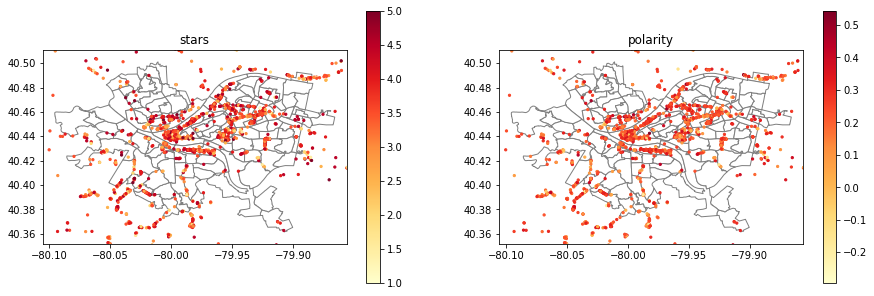

```python
plotMapTwo(HH_income_gdf, yelp_pittsburgh_business_merge,15, 5, "stars", "polarity")
```

We can observe similar spatial patterns of stars and polarity from the above subplots.

Note: the analysis is based on the **MUSA 620 Data Wrangling and Viusalization** - assignment 2 at University of Pennsylvania. The paragraphs are shamelessly stolen from the assignment notes.